# Chapter 7: Bonds

FINA 3000 · Business Finance I · Class 10

Dr. Justin Mohr

September 24, 2026

## Bonds

A long-term debt instrument in which a borrower agrees to make payments of principal and interest, on specific dates, to the holders of the bond.

- Very common financial instrument
  - Governments and firms issue them
  - States and cities do as well. These are called *munis* or municipal bonds
- Investors like because of stability
  - Why are bonds more stable?
  - Why should your portfolio switch towards bonds from equity as you age?

## Bonds

- Par value
  - Face
- Coupon rate
- Maturity Date
- Issue Date

[figure not shown]

## Bonds

- Par value
  - Face
- Coupon rate
- Maturity Date
- Issue Date

[figure not shown]

## Features of Bonds

- Par value: face amount of the bond, which is paid at maturity (assume $1,000)
- Coupon interest rate: stated interest rate paid by the issuer
  - Multiply by par value to get dollar payment of interest
- Maturity date: years until the bond must be repaid
- Issue date: when the bond was issued
- Yield to maturity: rate of return earned on a bond held until maturity (also called the “promised yield”)

## Other Features of Bonds

- Convertible bond: may be exchanged for common stock of the firm, at the holder’s option
  - Debt holders have the ability to become equity holders
  - Warrants: Similar, but only the right to purchase
- *Putable* bond: allows holder to sell the bond back to the company prior to maturity
  - We will spend more time talking about the counter-part callable bonds
- Income bond: pays interest only when interest is earned by the firm
  - Cannot bankrupt the firm
- Indexed bond: interest rate paid is based upon the rate of inflation
  - These are offered by the Treasury (TIPS)

## Interest rates

The discount rate on a bond is the opportunity cost of capital, and it is the rate that could be earned on alternative investments of equal risk.

$$r_i = r^* + IP + MRP + DRP + LP$$

- r* -Risk free rate: how much a perfectly riskless security would return
- IP -Inflation premium: expected rate of inflation
- MRP-Maturity risk premium: longer term bonds have a higher risk
- DRP-Default risk premium: likelihood of default
- LP -Liquidity premium: reflects how difficult it is to convert a bond to cash

Debt holders demand compensation for each of these!

## Bonds as a TVM problem

- Bonds are the perfect time value of money problem!
- Time 0
  - Bond is purchased for par value
- Time 1-Time N
  - Payments are made on the par value of the bond
  - Coupon rate
    - Not always the discount rate
- Time N
  - Final payment is made
  - Par Value is returned

## Bond Valuation

Justin’s Cupcakes is raising debt. After meeting with investors we agreed that 8% is a market rate for my riskiness. I decide to issue the 3 year note at 8% with payments of 80 dollars per year.

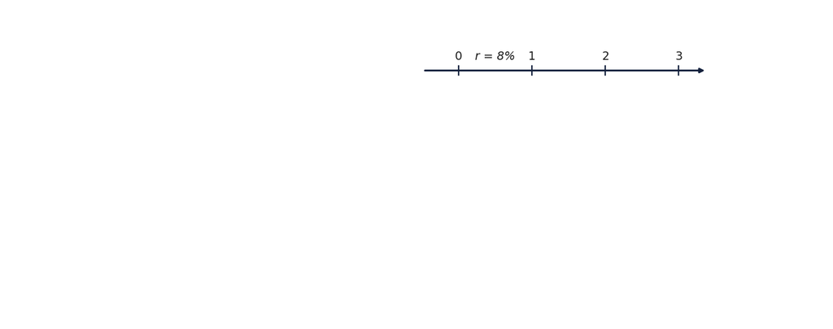

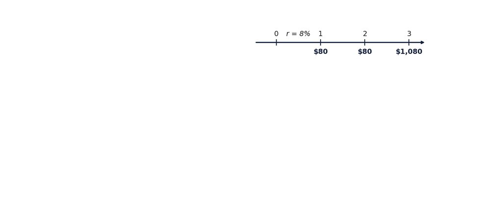

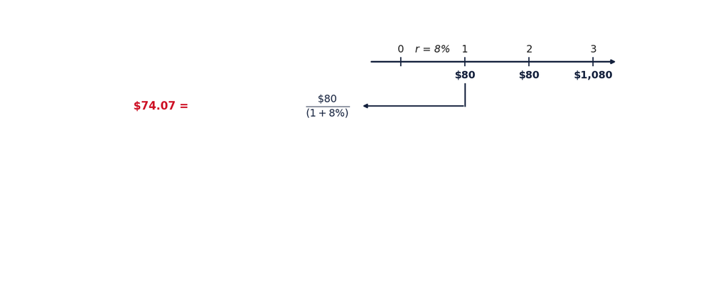

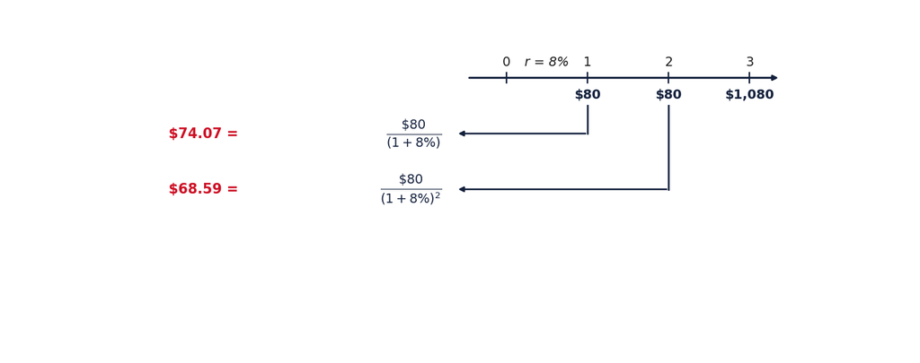

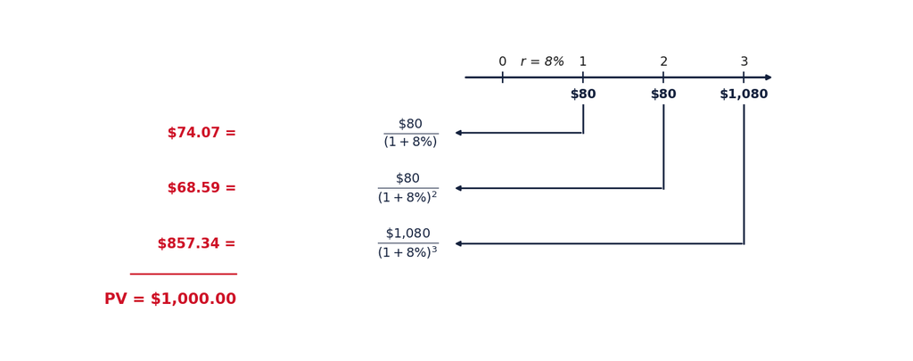

## Bond Valuation

Justin’s Cupcakes is raising debt. After meeting with investors we agreed that 8% is a market rate for my riskiness. I decide to issue the 15 year note at 8% with payments of 80 dollars per year.

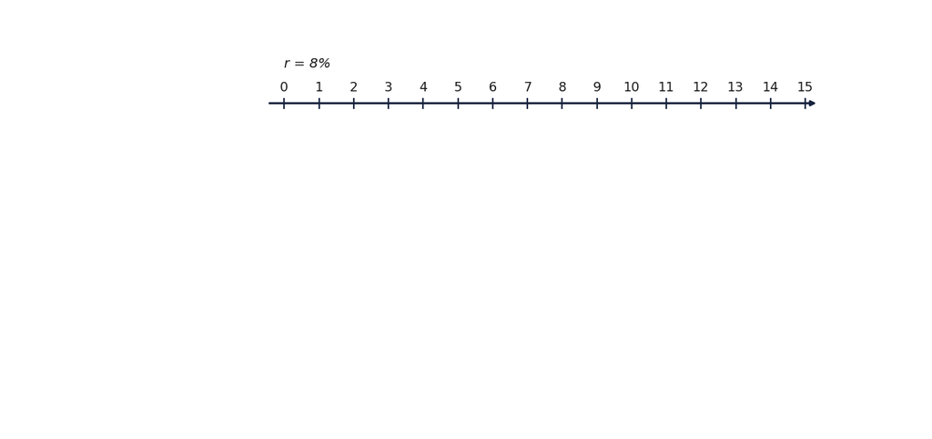

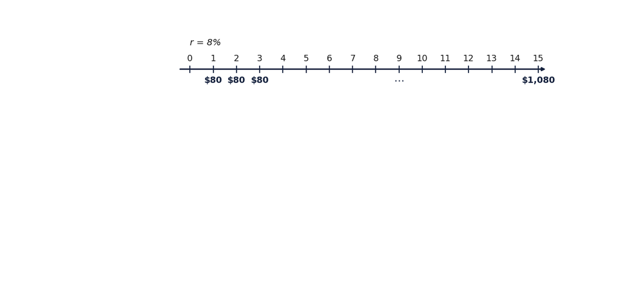

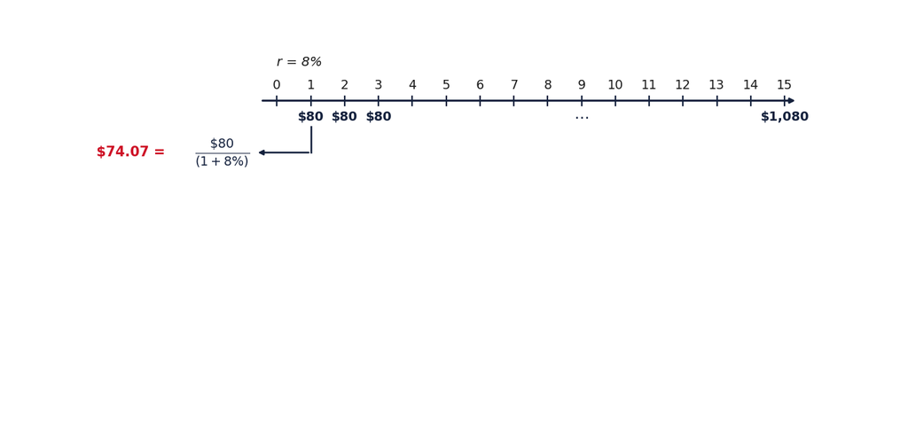

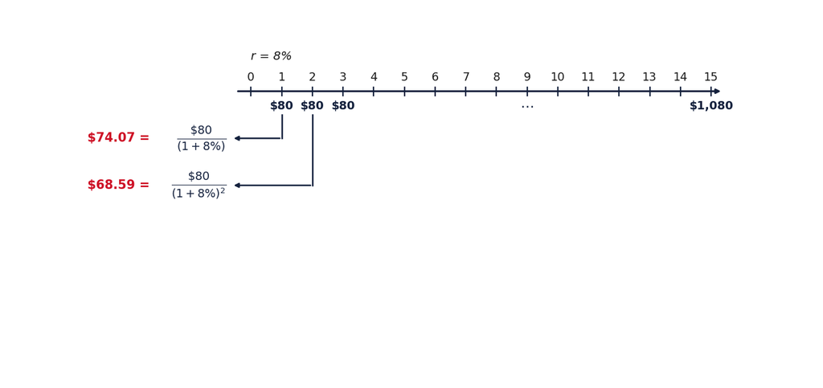

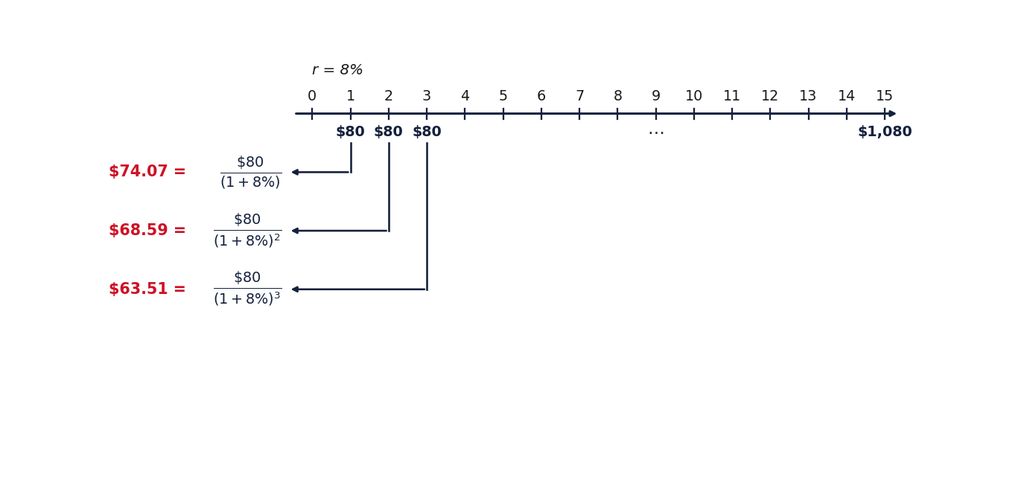

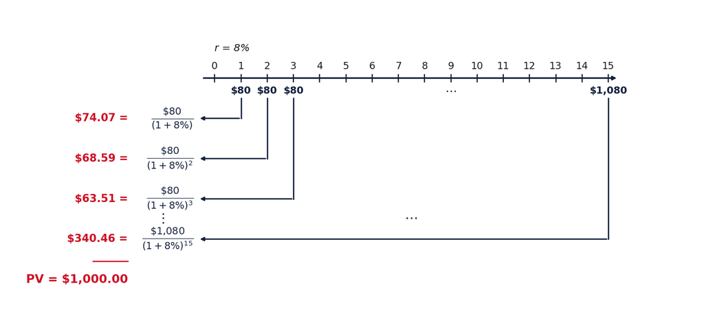

## Bond Valuation

Justin’s Cupcakes is raising debt. After meeting with investors we agreed that 8% is a market rate for my riskiness. I decide to issue the 15 year note at 8% with payments of 80 dollars per year. Using your calculator, find the PV of the bond.

N15I/Y8PV?PMT80FV1,000

CPT PV-1,000

## Secondary Bond Markets

- Bonds can be sold in secondary markets
  - Recall the LP
- The firm can have risks that change over time
  - Suppose that Justin’s Cupcakes increases the likelihood of bankruptcy
- If everything stays the same, then the price of the bond *never* changes

## Bond Prices Over Time

You want to sell the bond you purchased from Justin’s Cupcakes to another student. All risks have remained the same. The discount rate is still 8% and the payment is 80 dollars

There are 12 years left to maturity. What is the price of the bond?

N12I/Y8PV?PMT80FV1,000

CPT PV-1,000

Why is the price the same?

If risk never changes, then coupon rate=discount rate

## Bond Prices Over Time

You want to sell the bond you purchased from Justin’s Cupcakes to another student. The cupcake business has become riskier and the discount rate is now 11%. There are 12 years left to maturity. What is the price of the bond?

N12I/Y11PV?PMT80FV1,000

CPT PV-805.23

Why does the price go down?

- The coupon rate<discount rate, so investors are not willing to pay face value
- Trade at discount

## Bond Prices Over Time

You want to sell the bond you purchased from Justin’s Cupcakes to another student. The cupcake business has improved its financial position. The discount rate has fallen to 5%. There are 12 years left to maturity. What is the price of the bond?

N12I/Y5PV?PMT80FV1,000

CPT PV-1,265.90

Why does the price go up?

- The coupon rate>discount rate, so investors are willing to pay more for the bond
- Trade at premium

## Bond Prices and the Discount Rate

Price a bond with an 8% coupon at 15, 10, 5 and 1 year to maturity, at a 12% discount rate and at a 5% discount rate.

Price of an 8% coupon bond at two discount rates, by years to maturity

| Years to maturity | At 12% | At 5% |
| --- | --- | --- |
| 15 | $727.57 | $1,311.39 |
| 10 | $773.99 | $1,231.65 |
| 5 | $855.81 | $1,129.88 |
| 1 | $964.29 | $1,028.57 |

## Bond Ratings

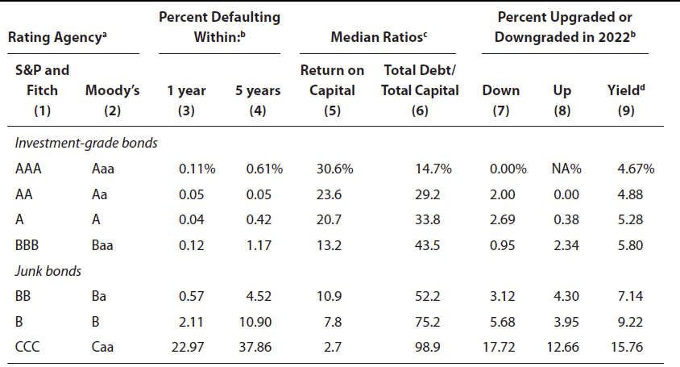

## Credit Spreads

[figure not shown]

## Risk and Return

Return is a reward for risk. I cannot get a return without risk.

Return is a reward for risk. I cannot get a return without risk.

Return is a reward for risk. I cannot get a return without risk.

Return is a reward for risk. I cannot get a return without risk.

Return is a reward for risk. I cannot get a return without risk.

## AA versus CCC

- AA bonds
  - 0.05% default in 5 years
  - That is 1 in 2000!
- CCC bonds
  - 37 percent default within 5 years
  - That is more than 1 in 3!

## A Warning

- Junk bonds are riskier this means that they get a higher rate of return
- When people invest in bonds they know that they have to accept lower returns (yields is the name of returns for bonds)
- You will see High Yield bond funds advertised

That is great! What bonds do we think make up these high yield funds?

Junk bonds.

## What happens when a company defaults

*Simplified*

- Creditor and Company might negotiate or Creditor goes to court to seize assets
- Company goes and files bankruptcy to stay collections on debts and negotiate settlement

## The Corporate Default Paradox

Mayra Rodriguez Valladares, Forbes, September 1. [Read the story](https://www.forbes.com/sites/mayrarodriguezvalladares/2026/09/01/the-corporate-default-paradox-markets-are-underpricing-credit-risk/)

- On the surface US corporate credit looks healthy
  - High-yield spreads **275 to 285 basis points** in late August, historically tight
  - Trailing twelve-month speculative-grade default rate **3.5% to 4.3%**
  - That is down from above **4.5%** in late 2023 and early 2024
  - Fitch puts the leveraged loan default rate at **3.9%**, flat month over month
- “That calm is the problem”

## Junk Bonds vs 10Y US Treasury Yields

[figure not shown]

## Junk Bond Spread over US Treasury Bonds

[figure not shown]

## Underpricing credit risk

What do we think will happen to firms with the Fed keeping rates high?

## The refinancing wall

- Trillions of corporate debt was issued at **3% to 4%** coupons in the ultra-low-rate years
- It has to be refinanced over the next **24 months**
- Most of it at prevailing yields of **7.5% to 9.5%**
- That repricing alone can gut free cash flow and capital budgets
- Some issuers look solvent today only because their debt has not come due yet

## Bonds and Bankruptcy

- Read Section 7-8 for a discussion of how debt holders manage default risk
- Mortgage bonds
  - These are bonds with specific assets pledged to them
- Debenture
  - Long term bond with no specific assets pledged to it
- Seniority
  - Senior debt holders are the first in line in the event of bankruptcy
  - Preferential as you get first dibs on the assets

## Bond Return

Last year Janet purchased a $1K face value bond with an 8% annual coupon rate and 15-years to maturity. At the time of the purchase, it had an expected yield to maturity of 10.45%. If Janet sold the bond today for $820.17, what would she earn from having owned the bond?

Hint: Find Purchase price, then CF while owning the bond.

N15I/Y10.45PV?PMT80FV1000

CPT PV-818.34

820.17 +80-818.34=81.83

81.83/818.34=10%

## Upcoming Dates

Upcoming class dates and deadlines

| Date | Topic | Due / Notes |
| --- | --- | --- |
| Sun Sep 27 | AI assignment | DUE |
| Tue Sep 29 | Chapter 7: Bonds | - |
| Thu Oct 1 | Chapter 8: Risk and Return | - |
| Sun Oct 4 | MindTap Ch 7 | HW DUE |

**Office:** 325 Holman Hall · **Office hours:** T TH 10:50A-12:20P · jjmohr1@olemiss.edu